# Practical Machine Learning Course project

Marco Colbacchini

31 luglio 2016

## Data Cleaning

Read the CSV training data set

```r
rm(list=ls())
set.seed(883)
library(data.table)
df1 <- read.csv("pml-training.csv",header=T, na.string=c("","NA","NULL"))
```

Check and adjust for NA vlues and near zero variance features.

```r
sum(colSums(is.na(df1))!= 0) # number of features containing NA values
```

```
## [1] 100
```

```r
NA_clean <- colSums(is.na(df1)) == 0
df1.clean <- df1[ , NA_clean]
library(caret)
preproc <- nearZeroVar(df1.clean, saveMetrics=TRUE)
names(df1.clean)[preproc$nzv] # names of features with n.z.v.
```

```
## [1] "new_window"
```

```r
nzv_clean <- which(preproc$nzv)
df1.clean <- df1.clean[,-nzv_clean]
```

101 variables have been delated because of NA values or small variance. In addition, by looking at the remaining variables seems that the firs seven are not of interest for this analysys.

```r
# Exclude unnecessary predictors
df1.clean <- df1.clean[,-(1:7)]
```

## Subsampling

Since the sample is relatively large is possible to reate three different sub-samples: training, testing and validation set.

```r
# Create training and Validation sets:
  # Create a building data set and validation set
inTrain <- createDataPartition(y=df1.clean$classe,p=0.6, list=FALSE)
training <- df1.clean[inTrain,]; buildData <- df1.clean[-inTrain,]
inTest <- createDataPartition(y=buildData$classe,p=0.5, list=FALSE)
testing <- buildData[inTest,]; validation <- buildData[-inTest,]
dim(training); dim(validation); dim(testing)
```

```
## [1] 11776    52
```

```
## [1] 3923   52
```

```
## [1] 3923   52
```

## Preliminary Analysis

```r
# Clean Memory
rm(df1);rm(df1.clean); rm(inTrain)
gc(); gc(verbose=T)
```

Five different algorithms are used to fit the training data set. These are: Tree, Gradient Boosting Machine (GBM), naive bayes, random forest and support vector machine (SVM).

```r
control <- trainControl(method="cv", number=2) # my old computer do not support anything better w/o running out of memory =(
set.seed(883)
# 1. Tree
modFit1 <- train(classe ~ ., method="rpart", data=training, trControl=control)
confusionMatrix(modFit1)
```

```
## Cross-Validated (2 fold) Confusion Matrix
##
## (entries are percentual average cell counts across resamples)
##
##           Reference
## Prediction    A    B    C    D    E
##          A 22.3  3.9  1.2  2.0  2.0
##          B  1.4  9.3  0.9  1.9  3.7
##          C  2.7  4.1 12.7  2.9  4.6
##          D  1.9  2.0  2.6  9.5  2.8
##          E  0.1  0.0  0.0  0.0  5.3
##
##  Accuracy (average) : 0.5908
```

```r
# 2. Boost (gbm)
modFit2 <- train(classe ~ ., method="gbm", data=training, verbose=FALSE, trControl=control)
confusionMatrix(modFit2)
```

```
## Cross-Validated (2 fold) Confusion Matrix
##
## (entries are percentual average cell counts across resamples)
##
##           Reference
## Prediction    A    B    C    D    E
##          A 28.0  0.8  0.0  0.0  0.0
##          B  0.2 17.7  0.6  0.1  0.3
##          C  0.1  0.7 16.5  0.7  0.3
##          D  0.1  0.1  0.3 15.5  0.2
##          E  0.0  0.1  0.1  0.1 17.5
##
##  Accuracy (average) : 0.9522
```

```r
# 3. Naive Bayes
modFit3 <- train(classe ~ ., method="nb",data=training, trControl=control)
confusionMatrix(modFit3)
```

```
## Cross-Validated (2 fold) Confusion Matrix
##
## (entries are percentual average cell counts across resamples)
##
##           Reference
## Prediction    A    B    C    D    E
##          A 22.3  2.7  2.5  2.1  0.7
##          B  0.9 12.8  1.2  0.0  1.8
##          C  2.3  2.3 13.0  2.7  0.9
##          D  2.6  1.3  0.6 10.6  0.8
##          E  0.3  0.3  0.2  1.0 14.1
##
##  Accuracy (average) : 0.727
```

```r
# 4. Random Forest
modFit4 <- train(classe ~ .,data=training, method="rf", trControl=control, ntree=500 )
confusionMatrix(modFit4)
```

```
## Cross-Validated (2 fold) Confusion Matrix
##
## (entries are percentual average cell counts across resamples)
##
##           Reference
## Prediction    A    B    C    D    E
##          A 28.3  0.4  0.0  0.0  0.0
##          B  0.1 18.8  0.4  0.0  0.0
##          C  0.0  0.2 16.9  0.3  0.1
##          D  0.0  0.0  0.1 16.0  0.1
##          E  0.0  0.0  0.0  0.0 18.2
##
##  Accuracy (average) : 0.9821
```

```r
# 5. Support Vector Machine
library(e1071)
f <- formula("classe ~ .")
modFit5 <- svm(f, data=training)
```

Performance of the various algorithm are compared using the accuracy rate on the testing set.

```r
pred1 <- predict(modFit1,testing)
tree <- sum(pred1==testing$classe)/length(pred1)
pred2 <- predict(modFit2,testing)
boost <- sum(pred2==testing$classe)/length(pred2)
pred3 <- predict(modFit3, testing)
nb <- sum(pred3==testing$classe)/length(pred3)
pred4 <- predict(modFit4, testing)
rf <- sum(pred4==testing$classe)/length(pred4)
pred5 <- predict(modFit5, testing)
svm <- sum(pred5==testing$classe)/length(pred5)

x<-c(tree=tree,boost=boost,nb=nb,rf=rf,svm=svm)
print(x)
```

```
##      tree     boost        nb        rf       svm
## 0.5651287 0.9559011 0.7387204 0.9900586 0.9383125
```

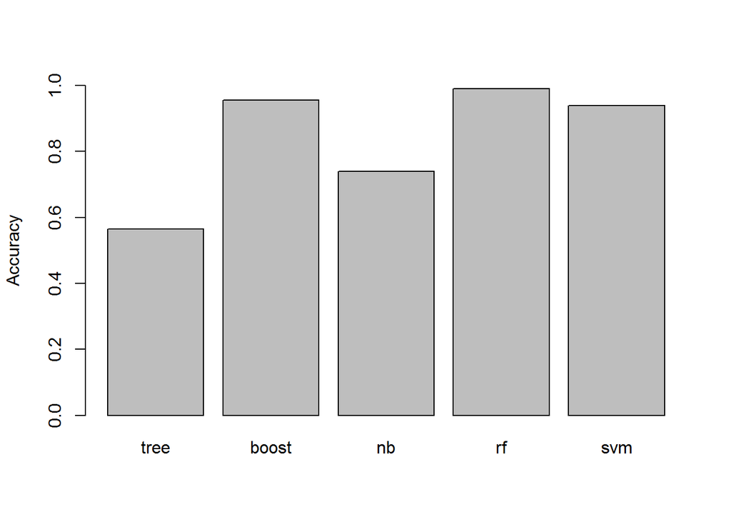

```r
barplot(height=x, ylab = "Accuracy", ylim=c(0,1))
```

The random foret is by far the most accurate model, followed by GBM and SVM. So far all eligible features have been used. However some pre-pocessing of the data may improve the model if features are correlated or capture too much the noise in the data. Expecially the SVM model may be haighly influenced by correlation in the features.

## Pre-processing

```r
# Analyzing correlation among features.
quantile( cor(training[,-52]), probs=c(0,0.1,0.9,1))
```

```
##         0%        10%        90%       100%
## -0.9868601 -0.2571346  0.3203131  1.0000000
```

```r
mat <- abs(cor(training[,-52]))
diag(mat) <- 0; sum(mat > 0.8)/2
```

```
## [1] 15
```

Many features are highly correlated and 15 pairs have a correlation bigger than 0.8. Principal component analysis may be a good method to adress the redundancy in the data and it may also reduce the computation power reqired. First, the cumulative explained variancve of the principal components is plotted.

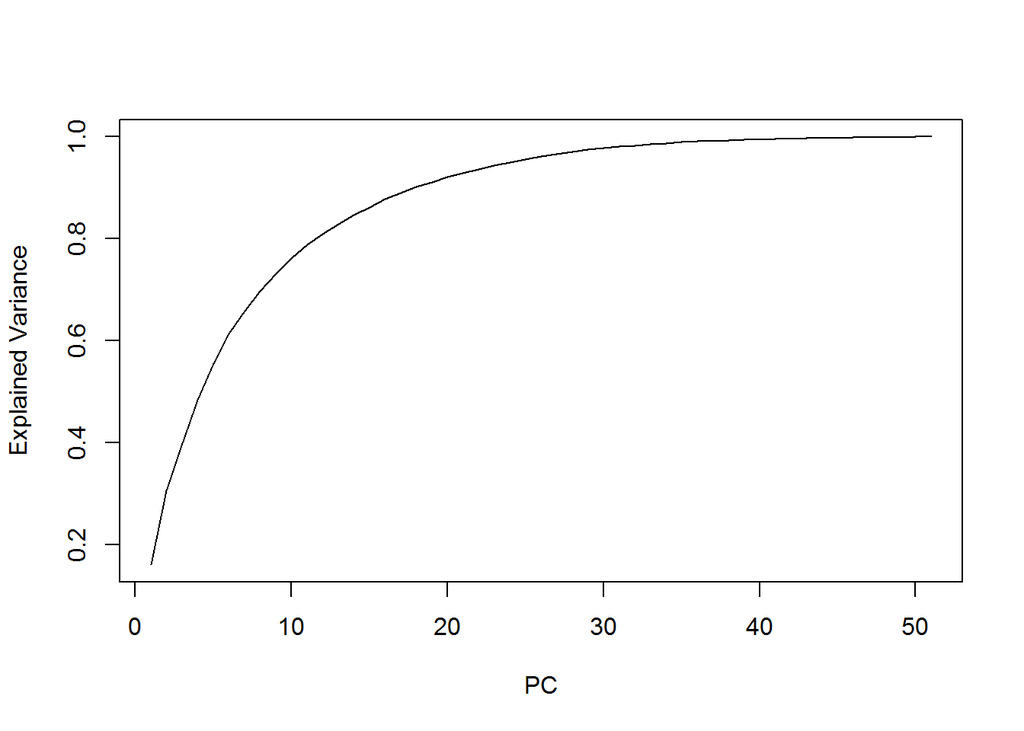

```r
pc <- prcomp(training[,-52],center=T,scale=T)
cumulativeV <- cumsum(pc$sdev^2/sum(pc$sdev^2))
plot(cumulativeV, type="l", xlab="PC",ylab="Explained Variance")
```

In order to retain 90% of the variation 20 pincipal components are required. New sub-samples sets are obteined by applying PCA on the training set.

```r
preProc <- preProcess(training[,-52], method="pca", thresh = 0.9)
training.pc <- cbind( predict(preProc,training[,-52]), classe = training$classe)
testing.pc <- cbind(predict(preProc,testing[,-52]) , classe = testing$classe)
validation.pc <- cbind(predict(preProc,validation[,-52]) , classe = validation$classe)
```

## Models Analysis

```r
# Clean memory
rm(modFit1); rm(modFit3) # Discard bad models
gc(); gc(verbose=T)
```

Now all modells are estimated once again, using principal components instead of the original features.

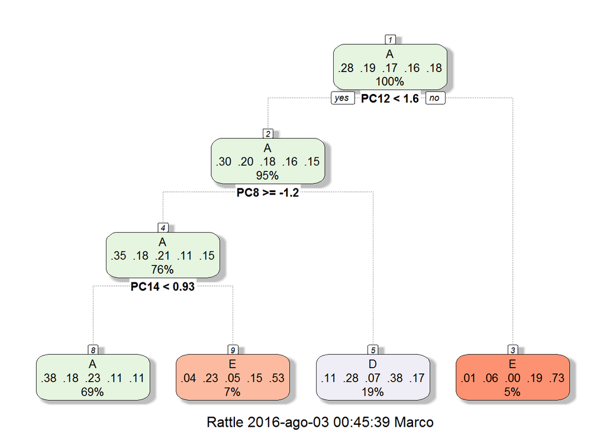

```r
set.seed(883)
# 1. Tree
modFit6 <- train(classe ~ ., method="rpart", data=training.pc, trControl=control)
library(rattle); fancyRpartPlot(modFit6$finalModel, cex=.8)
```

```r
confusionMatrix(modFit6)
```

```
## Cross-Validated (2 fold) Confusion Matrix
##
## (entries are percentual average cell counts across resamples)
##
##           Reference
## Prediction    A    B    C    D    E
##          A 26.0 12.1 15.6  7.3  7.6
##          B  0.0  1.4  0.2  0.5  0.6
##          C  0.0  0.0  0.0  0.0  0.0
##          D  2.0  3.7  1.2  6.4  2.5
##          E  0.4  2.1  0.5  2.2  7.7
##
##  Accuracy (average) : 0.4156
```

```r
# 2. Boost (gbm)
modFit7 <- train(classe ~ ., method="gbm", data=training.pc, verbose=FALSE, trControl=control)
confusionMatrix(modFit7)
```

```
## Cross-Validated (2 fold) Confusion Matrix
##
## (entries are percentual average cell counts across resamples)
##
##           Reference
## Prediction    A    B    C    D    E
##          A 24.5  2.3  1.5  0.8  0.7
##          B  1.1 13.9  1.5  0.5  2.0
##          C  1.0  1.9 13.4  1.8  1.4
##          D  1.6  0.7  0.6 12.6  0.8
##          E  0.3  0.5  0.4  0.6 13.5
##
##  Accuracy (average) : 0.7793
```

```r
# 3. Naive Bayes
modFit8 <- train(classe ~ ., method="nb",data=training.pc, trControl=control)
confusionMatrix(modFit8)
```

```
## Cross-Validated (2 fold) Confusion Matrix
##
## (entries are percentual average cell counts across resamples)
##
##           Reference
## Prediction    A    B    C    D    E
##          A 17.6  2.0  3.8  1.4  1.0
##          B  2.4 11.0  1.6  1.1  3.4
##          C  4.6  3.0  9.7  2.9  1.9
##          D  3.3  2.3  1.0  9.9  1.5
##          E  0.6  1.0  1.4  1.1 10.5
##
##  Accuracy (average) : 0.587
```

```r
# 4. Random Forest
modFit9 <- train(classe ~ .,data=training.pc, method="rf", trControl=control)
confusionMatrix(modFit9)
```

```
## Cross-Validated (2 fold) Confusion Matrix
##
## (entries are percentual average cell counts across resamples)
##
##           Reference
## Prediction    A    B    C    D    E
##          A 27.6  0.7  0.2  0.2  0.1
##          B  0.2 17.8  0.6  0.1  0.3
##          C  0.2  0.7 16.1  1.1  0.3
##          D  0.3  0.1  0.3 14.9  0.2
##          E  0.1  0.1  0.2  0.1 17.5
##
##  Accuracy (average) : 0.9392
```

```r
# 5. Support Vector Machine
library(e1071)
f <- formula("classe ~ .")
modFit10 <- svm(f, data=training.pc)
```

```r
pred6 <- predict(modFit6,testing.pc)
treePC <- sum(pred6==testing.pc$classe)/length(pred6)
pred7 <- predict(modFit7,testing.pc)
boostPC <- sum(pred7==testing.pc$classe)/length(pred7)
pred8 <- predict(modFit8, testing.pc)
nbPC <- sum(pred8==testing.pc$classe)/length(pred8)
pred9 <- predict(modFit9, testing.pc)
rfPC <- sum(pred9==testing.pc$classe)/length(pred9)
pred10 <- predict(modFit10, testing.pc)
svmPC <- sum(pred10==testing.pc$classe)/length(pred10)

x<-c(tree=treePC,boost=boostPC,nb=nbPC,rf=rfPC,svm=svmPC)
print(x)
```

```
##      tree     boost        nb        rf       svm
## 0.4027530 0.7902116 0.5964823 0.9632934 0.8988019
```

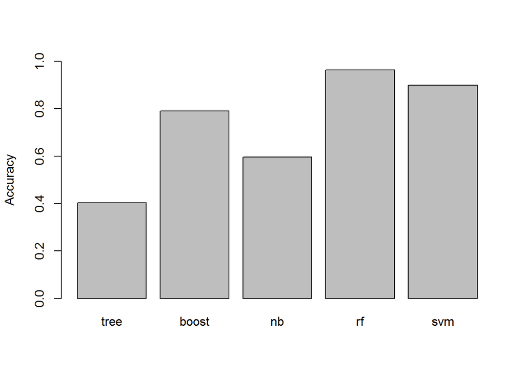

```r
barplot(height=x, ylab = "Accuracy", ylim=c(0,1))
```

The accuracy is smaller for all modells in comparison to the scenario which included all features. This is true even for the svm model. Apparently the major benefit of using PCA is a gain in computational speed.

## Combining Predictors

The best 3 models are combined using random forest. These are boost, random forest and svm. The testing dataset containing all variacles is used for training (i.e no PCA). Now is not possible anymore to compute the accuracy on the testing set because it may incorporate overfitting, thus the validation set is used instead.

```r
model2 <- predict(modFit2, testing)
model4 <- predict(modFit4, testing)
model5 <- predict(modFit5, testing)
df <- data.frame(model2,model4,model5,classe=testing$classe)
fitComb <- train(classe ~ ., data=df, method="rf", trControl=control)
predComb <- predict(fitComb, validation)
accuracy <- sum(predComb==validation$classe)/length(predComb)
print(accuracy)
```

```
## [1] 0.9905684
```

```r
# comparison with random forest alone
print(rf)
```

```
## [1] 0.9900586
```

By combining the predictors there is a really small accuracy gain. However the accuracy is almost equal to the random forest stand-alone model.

## Quiz Prediction

The combined model is used to predict the classe variable for the second dataset provided.

```r
# import and clean data
df2 <- read.csv("pml-testing.csv",header=T, na.string=c("","NA","NULL"))
df2.clean <- df2[ , NA_clean]
df2.clean <- df2.clean[,-nzv_clean]
df2.clean <- df2.clean[,-(1:7)]
colnames(df2.clean)[52] <- "classe"
# single model predictions
tmp1 <- predict(modFit2, df2.clean)
tmp2 <- predict(modFit4, df2.clean)
tmp3 <- predict(modFit5, df2.clean)
# Combined prediction
tmpdf <- data.frame(model2=tmp1,model4=tmp2,model5=tmp3,classe=df2.clean$classe)
answer2 <- predict(fitComb, tmpdf)
print(answer2)
```

```
##  [1] B A B A A E D B A A B C B A E E A B B B
## Levels: A B C D E
```

Accuraci (according to the quiz solutions) is 1.